# **Reducing the Number of High Fatality Accidents in the UK**

Can Data Analysis Inform Interventions to Reduce High Fatality Road Accidents?

John King’athia Karuitha (diakingathia2005@gmail.com)

Monday, January 03, 2022

# **Summary**

In this project, I use data from the Department of Transport in the United Kingdom (UK) to derive insights to reduce fatalities from major accidents. Specifically, the project aims to identify factors associated with road accidents fatalities. The key findings are:

- Accident casualties peak during weekends, Starting from Friday and falling on Sunday.
- Accidents casualties vary by time of day.
- Major accidents and accident casualties mainly happen when the weather is fine.
- Major accidents and accident casualties mainly occur in road stretches with speed limits of 30 mph and 60 mph.

The project proceeds by laying out the background first, followed by exploratory data analysis. The project then delves into the data analysis to garner insights. The project then concludes.

# **Background**

The [World Health Organization (WHO)](https://www.who.int/news-room/fact-sheets/detail/road-traffic-injuries) estimates that approximately 1.3 million people globally die in road accidents every year. Road accidents occur in every country. However, about 93% of the accidents happen in low- and middle-income countries, with 60% of the total vehicles in the world. The monetary loss occasioned by these road accidents amounts to about 3% of the GDP of each country. Importantly, road accidents are the leading cause of death for children and young adults between 5-29 years. The social and economic costs associated with road accidents make it paramount to craft strategies to reduce the number of road accidents and, critically, the fatalities. Coincidentally, at the time of writing this article, the United Nations is leading the world in commemorating victims of [road accidents on Sunday, November 21, 2021](https://www.un.org/en/observances/road-traffic-victims-day), dubbed the `World Day of Remembrance for Road Traffic Victims`.

See the WHO summary on road accidents fatalities on https://www.who.int/news-room/fact-sheets/detail/road-traffic-injuries

See https://www.un.org/en/observances/road-traffic-victims-day for further information about World remembrance day, which happens annually on the third Sunday of November.

In this article, I use data from the department of transport in the UK to garner insights into road accidents and associated fatalities. As a (fictional) employee of the road safety team in the department, my task is to use data to develop insights that would help reduce the number and fatalities of major incidents. Major accidents have at least three casualties. The department seeks to uncover the characteristics of these major incidents to brainstorm interventions that could lower the number of deaths. To this end, the department has asked me to examine the data and answer the following questions.

1. What time of day and day of the week do most major incidents happen?
2. Are there any patterns in the time of day/ day of the week when major incidents occur?
3. What characteristics stand out in major incidents compared with other accidents?
4. On what areas would I recommend the planning team focus their brainstorming efforts to reduce major incidents?

NB: Please click on `code` to unhide the `R` code underlying the results presented.

# **Data**

The reporting department has been collecting data on every reported accident. They’ve included this along with a lookup file for 2020’s accidents. I start by reading in both data sets into `R`.

*Published by the department for transport. , https://data.gov.uk/dataset/road-accidents-safety-data.* *Contains public sector information licensed under the Open Government Licence v3.0.*

```r
## Read in the accidents data from the data folder.
accidents <- read_csv("data/accident-data.csv", na = "-1") %>%

  ## Convert date and time to date/time format
  mutate(date = dmy(date),

         time = hms(time)) %>%

  mutate(day_of_week = factor(day_of_week,

                              labels = c("Sun", "Mon", "Tue",

                                         "Wed", "Thur", "Fri", "Sat")))

## Structure of the accidents data.
#str(accidents)

## Read in the accidents data from the data folder.
lookup <- read_csv("data/road-safety-lookups.csv")

## Structure of the lookup data
#str(lookup)
```

The `accidents` table has 27 variables and 91199 observations. The `lookup` table has 5 variables, and 129 observations contains the metadata for the main data set, `accidents`.

I begin by examining the data, with reference to missing values and possible duplicates. Table 1 below variables with missing data points and the corresponding number of missing observations.

```r
sapply(accidents, is.na) %>%

  colSums() %>%

  tibble(variable_name = names(accidents), missing = .) %>%

  arrange(desc(missing)) %>%

  filter(missing > 0) %>%

  kbl(., booktabs = TRUE, caption = "Table 1: Missing Values") %>%

  kable_classic(full_width = FALSE,

                latex_options = "hold_position", position = "left")
```

Table 1: Missing Values

| variable_name | missing |
| --- | --- |
| junction_control | 38298 |
| road_surface_conditions | 316 |
| special_conditions_at_site | 218 |
| carriageway_hazards | 208 |
| pedestrian_crossing_human_control | 143 |
| pedestrian_crossing_physical_facilities | 135 |
| longitude | 14 |
| latitude | 14 |
| speed_limit | 12 |
| second_road_number | 7 |
| junction_detail | 2 |
| light_conditions | 1 |
| weather_conditions | 1 |

The data set is reasonably complete except for a glaring gaps in the junction control variable.

```r
accidents %>%

        filter(duplicated(.))
```

```
## # A tibble: 0 × 27
## # … with 27 variables: accident_index <chr>, accident_year <dbl>,
## #   accident_reference <chr>, longitude <dbl>, latitude <dbl>,
## #   accident_severity <dbl>, number_of_vehicles <dbl>,
## #   number_of_casualties <dbl>, date <date>, day_of_week <fct>, time <Period>,
## #   first_road_class <dbl>, first_road_number <dbl>, road_type <dbl>,
## #   speed_limit <dbl>, junction_detail <dbl>, junction_control <dbl>,
## #   second_road_class <dbl>, second_road_number <dbl>, …
```

Again, the data has no duplicate rows that may indicate an accident captured more than once.

# **Data Exploration**

We summarise the variables in Appendix 1. For these summary statistics, I have eliminated some variables that would yield no meaningful information when summarised, for instance, longitude and latitude. Table 2 below shows the correlation matrix. Of interest are variables with higher correlations with `number of casualties`, the target variable, while bearing in mind that correlation may not capture non-linear relationships. The two variables that show a high correlation with `number of casualties` are `number of vehicles` involved in an accident (0.197) and `speed limit` (0.153).

```r
accidents %>%

        ## Seselect redunndant variables
        select(-accident_index, -accident_reference,

         -accident_year, -day_of_week,

         -date, -time,

         -longitude, -latitude, -junction_control) %>%

  relocate(number_of_casualties) %>%

        ## Remove NA rows
        na.omit() %>%

        ## Do correlation and a nice table.
        cor() %>%

        data.frame() %>%

        ## Make a nice table
        kbl(., booktabs = TRUE, caption = "Table 2: Correlation Matrix") %>%

        kable_classic(full_width = TRUE,

                      latex_options = "hold_position",

                      font_size = 12)
```

Table 2: Correlation Matrix

|  | number_of_casualties | accident_severity | number_of_vehicles | first_road_class | first_road_number | road_type | speed_limit | junction_detail | second_road_class | second_road_number | pedestrian_crossing_human_control | pedestrian_crossing_physical_facilities | light_conditions | weather_conditions | road_surface_conditions | special_conditions_at_site | carriageway_hazards | urban_or_rural_area |
| --- | --- | --- | --- | --- | --- | --- | --- | --- | --- | --- | --- | --- | --- | --- | --- | --- | --- | --- |
| number_of_casualties | 1.0000000 | -0.0721619 | 0.1969233 | -0.0714877 | 0.0153349 | -0.0107753 | 0.1527840 | -0.0345430 | 0.0099575 | 0.0039677 | -0.0460355 | -0.0528777 | 0.0286223 | -0.0148285 | 0.0007400 | -0.0258306 | -0.0274437 | 0.1179114 |
| accident_severity | -0.0721619 | 1.0000000 | 0.0765725 | 0.0055638 | -0.0127589 | -0.0250227 | -0.1179176 | 0.0586559 | -0.0502471 | 0.0154857 | 0.0708365 | 0.0596644 | -0.0410348 | 0.0314524 | 0.0220876 | 0.0306033 | 0.0279883 | -0.1142710 |
| number_of_vehicles | 0.1969233 | 0.0765725 | 1.0000000 | -0.1003126 | -0.0033644 | -0.0532482 | 0.0361490 | 0.0068868 | -0.0258223 | 0.0111854 | -0.0060495 | -0.0284160 | -0.0664975 | -0.0384941 | -0.0443865 | -0.0214656 | -0.0326423 | -0.0042463 |
| first_road_class | -0.0714877 | 0.0055638 | -0.1003126 | 1.0000000 | -0.2636545 | 0.2800455 | -0.3050582 | 0.0022734 | 0.1607087 | -0.0682004 | -0.0458736 | -0.1268533 | -0.0406602 | -0.0075801 | -0.0284158 | -0.0301590 | -0.0206088 | -0.1576744 |
| first_road_number | 0.0153349 | -0.0127589 | -0.0033644 | -0.2636545 | 1.0000000 | -0.0062438 | -0.0106682 | -0.0250309 | -0.0206893 | 0.1205800 | -0.0381798 | 0.0296077 | 0.0003184 | -0.0055519 | -0.0060280 | -0.0209807 | -0.0215060 | 0.0145706 |
| road_type | -0.0107753 | -0.0250227 | -0.0532482 | 0.2800455 | -0.0062438 | 1.0000000 | -0.1667396 | 0.1141511 | 0.2361954 | -0.1085774 | 0.1010956 | 0.0085348 | -0.0115504 | 0.0387163 | 0.0718363 | 0.0750697 | 0.0973123 | -0.0354984 |
| speed_limit | 0.1527840 | -0.1179176 | 0.0361490 | -0.3050582 | -0.0106682 | -0.1667396 | 1.0000000 | -0.1425347 | 0.0316116 | -0.0262743 | -0.1438059 | -0.2448763 | 0.0757321 | -0.0129455 | 0.0306953 | -0.0411696 | -0.0407497 | 0.6712973 |
| junction_detail | -0.0345430 | 0.0586559 | 0.0068868 | 0.0022734 | -0.0250309 | 0.1141511 | -0.1425347 | 1.0000000 | -0.0636442 | 0.0152162 | 0.3544493 | 0.2683532 | 0.0007763 | 0.0871323 | 0.1406350 | 0.2370999 | 0.2327765 | -0.1336158 |
| second_road_class | 0.0099575 | -0.0502471 | -0.0258223 | 0.1607087 | -0.0206893 | 0.2361954 | 0.0316116 | -0.0636442 | 1.0000000 | -0.4933114 | -0.0678294 | -0.1829637 | 0.0042322 | -0.0127644 | -0.0079091 | -0.0260785 | -0.0093906 | 0.0406732 |
| second_road_number | 0.0039677 | 0.0154857 | 0.0111854 | -0.0682004 | 0.1205800 | -0.1085774 | -0.0262743 | 0.0152162 | -0.4933114 | 1.0000000 | -0.0060260 | 0.0903749 | -0.0015055 | -0.0005098 | -0.0072195 | -0.0084799 | -0.0164678 | -0.0236122 |
| pedestrian_crossing_human_control | -0.0460355 | 0.0708365 | -0.0060495 | -0.0458736 | -0.0381798 | 0.1010956 | -0.1438059 | 0.3544493 | -0.0678294 | -0.0060260 | 1.0000000 | 0.4717488 | 0.0199994 | 0.1619721 | 0.2652731 | 0.4018395 | 0.3895807 | -0.1348956 |
| pedestrian_crossing_physical_facilities | -0.0528777 | 0.0596644 | -0.0284160 | -0.1268533 | 0.0296077 | 0.0085348 | -0.2448763 | 0.2683532 | -0.1829637 | 0.0903749 | 0.4717488 | 1.0000000 | 0.0039691 | 0.0872577 | 0.1495177 | 0.2434098 | 0.2392031 | -0.2708051 |
| light_conditions | 0.0286223 | -0.0410348 | -0.0664975 | -0.0406602 | 0.0003184 | -0.0115504 | 0.0757321 | 0.0007763 | 0.0042322 | -0.0015055 | 0.0199994 | 0.0039691 | 1.0000000 | 0.1130786 | 0.1535566 | 0.0314279 | 0.0393104 | 0.0485156 |
| weather_conditions | -0.0148285 | 0.0314524 | -0.0384941 | -0.0075801 | -0.0055519 | 0.0387163 | -0.0129455 | 0.0871323 | -0.0127644 | -0.0005098 | 0.1619721 | 0.0872577 | 0.1130786 | 1.0000000 | 0.3575300 | 0.1616110 | 0.1713398 | -0.0146518 |
| road_surface_conditions | 0.0007400 | 0.0220876 | -0.0443865 | -0.0284158 | -0.0060280 | 0.0718363 | 0.0306953 | 0.1406350 | -0.0079091 | -0.0072195 | 0.2652731 | 0.1495177 | 0.1535566 | 0.3575300 | 1.0000000 | 0.3159680 | 0.3500860 | 0.0136347 |
| special_conditions_at_site | -0.0258306 | 0.0306033 | -0.0214656 | -0.0301590 | -0.0209807 | 0.0750697 | -0.0411696 | 0.2370999 | -0.0260785 | -0.0084799 | 0.4018395 | 0.2434098 | 0.0314279 | 0.1616110 | 0.3159680 | 1.0000000 | 0.5112938 | -0.0354214 |
| carriageway_hazards | -0.0274437 | 0.0279883 | -0.0326423 | -0.0206088 | -0.0215060 | 0.0973123 | -0.0407497 | 0.2327765 | -0.0093906 | -0.0164678 | 0.3895807 | 0.2392031 | 0.0393104 | 0.1713398 | 0.3500860 | 0.5112938 | 1.0000000 | -0.0404989 |
| urban_or_rural_area | 0.1179114 | -0.1142710 | -0.0042463 | -0.1576744 | 0.0145706 | -0.0354984 | 0.6712973 | -0.1336158 | 0.0406732 | -0.0236122 | -0.1348956 | -0.2708051 | 0.0485156 | -0.0146518 | 0.0136347 | -0.0354214 | -0.0404989 | 1.0000000 |

# **The Analysis**

In this section, we examine each of the questions in the analysis. I start by mapping out the areas where major fatal accidents happen- the hotspots. In this case, I use the density (2D) plot and the hexagonal heat map of 2D bin counts (geom_hex). The visualisation in Figure 1 shows that accidents happen all over the UK. However, there are hotspots where major accidents (with at least three casualties) are concentrated, leading us to our first insight. Figure 1 shows these accidents hotspots.

See https://www.google.com/url?sa=t&rct=j&q=&esrc=s&source=web&cd=&cad=rja&uact=8&ved=2ahUKEwjpv8Kkp8f0AhXHDGMBHXKKCPsQFnoECAIQAQ&url=https%3A%2F%2Fggplot2.tidyverse.org%2Freference%2Fgeom_hex.html&usg=AOvVaw1k9D7ncWuUhdgbBeCkxFWQ for details on hexagonal heat maps.

Figure 1: Major Accidents Hotspots in the UK

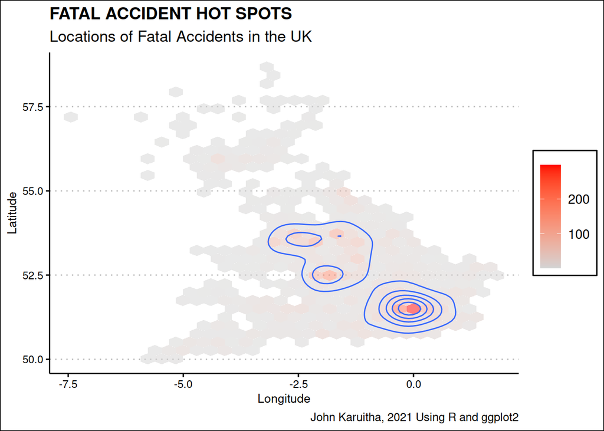

```r
accidents %>%

        ## Filter out major accidents
        filter(number_of_casualties >= 3) %>%

        ## Plot locations of major accidents
        ggplot(mapping = aes(x = longitude, y = latitude)) +

         ## Add a hex geom
        geom_hex(alpha = 0.5) +

        ## Add a gem dendity 2D
        geom_density_2d() +

        ## Add labels and titles
        labs(x = "Longitude", y = "Latitude",

       title = "FATAL ACCIDENT HOT SPOTS",

       subtitle = "Locations of Fatal Accidents in the UK",

       caption = "John Karuitha, 2021 Using R and ggplot2") +

  theme(legend.title = element_blank()) +

  scale_fill_gradient(low = "lightgray", high = "red")
```

**Insight 1**: Major accidents happen all over the UK. However, the graph shows two primary regions with an unusually high concentration of accidents and fatalities. One of these regions is in the south-east (presumably around London) while the other region spans Central UK. The accident hot spot in the central UK has three key sub-areas where accidents concentrate. There are additional pockets of accident hotspots, one towards the North East and another to the North(Scotland).

We also examine the distribution of the accident fatalities, given that this is the target variable. Figure 2 is a histogram of the distribution of accident fatalities.

Figure 2: Distribution of Accident Casualties in the UK

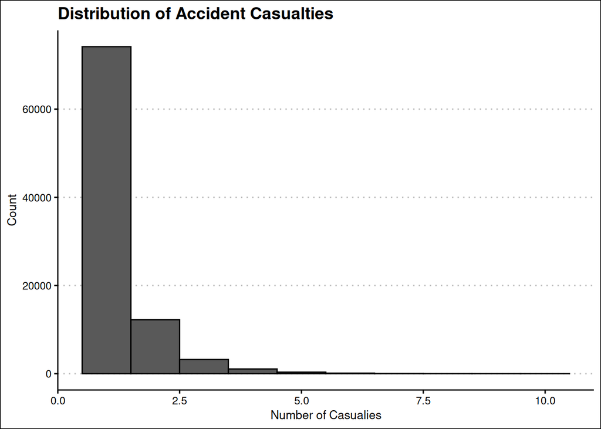

```r
accidents %>%

        ## Filter out the major accidents
        filter(number_of_casualties <= 10) %>%

        ## Do a histogram of casualties
        ggplot(mapping = aes(x = as.integer(number_of_casualties))) +

  geom_histogram(binwidth = 1, col = "black") +

        scale_fill_okabe_ito(name = "Cylinders", alpha = .9) +

        scale_color_okabe_ito(name = "Cylinders") +

        labs(x = "Number of Casualies",

             y = "Count", title = "Distribution of Accident Casualties")
```

```r
accidents %>%

  mutate(major = case_when(

    number_of_casualties <= 3 ~ "Minor",

    TRUE ~ "Major"
  )) %>%

  group_by(major) %>%

  summarise(casualties = sum(number_of_casualties)) %>%

  mutate(prop = glue("{round(casualties / sum(casualties) * 100, 2)}%")) %>%

  kbl(., booktabs = TRUE,

  caption = "Table 3: Proportion of Deaths from Major and Minor Accidents") %>%

        kable_classic(full_width = FALSE,
                                                                                     latex_options = "hold_position", position = "left")
```

Table 3: Proportion of Deaths from Major and Minor Accidents

| major | casualties | prop |
| --- | --- | --- |
| Major | 7339 | 6.35% |
| Minor | 108245 | 93.65% |

Next, I examine the weekdays and times that major accidents happen most frequently.

## What time of day and day of the week do most major incidents happen?

Suppose there is a pattern in the weekdays or hours where major accidents happen. In that case, this could prove a significant entry point for interventions to minimise accident casualties. This section examines the prevalence of accidents and casualties by day of the week and time of day.

### What day of the week do most fatal accidents happen?

This section only examines the major accidents with at least three casualties. Figure 3 below shows the number of accidents and associated deaths for each day of the week. Weekends have markedly higher numbers of accidents and casualties. However, weekdays do have substantial numbers of accidents and fatalities as well. It is also notable but not surprising that the number of accidents correlates with the number of accidents. To this end, I do scatter plots of the number of accidents/casualties against the weekday.

Figure 3: Number of Major Accidents by Week Day

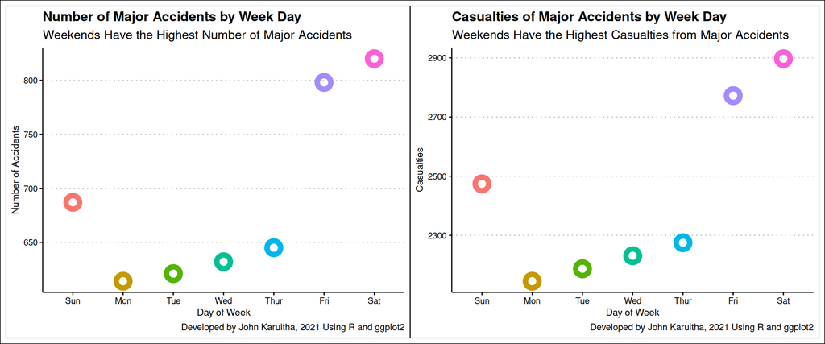

```r
(
### GRAPH 1: Number of Accidents.
accidents %>%

  ## Only major accidents with casualties >= 3.
  filter(number_of_casualties >= 3) %>%

  ## We want to see which day of week has more casualties.
  group_by(day_of_week) %>%

  ## Summary of total deaths by day of the week.
  summarise(accidents = n()) %>%

  ## plot casualties versus week day, colored by week day.
  ggplot(mapping = aes(x = day_of_week, y = accidents,

                       col = factor(day_of_week))) +

  ## Scatter plot.
  geom_point(shape = 1, size = 4, stroke = 4, show.legend = FALSE) +

  ## Axis labels, title and caption
  labs(x = "Day of Week", y = "Number of Accidents",

       title = "Number of Major Accidents by Week Day",

       subtitle = "Weekends Have the Highest Number of Major Accidents",

       caption = "Developed by John Karuitha, 2021 Using R and ggplot2") +

#############################################################################
### GRAPH 2: Number of Casualties.

accidents %>%

  ## Only major accidents with casualties >= 3.
  filter(number_of_casualties >= 3) %>%

  ## We want to see which day of week has more casualties.
  group_by(day_of_week) %>%

  ## Summary of total deaths by day of the week.
  summarise(casualties = sum(number_of_casualties)) %>%

  ## plot casualties versus week day, colored by week day.
  ggplot(mapping = aes(x = day_of_week, y = casualties,

                       col = factor(day_of_week))) +

  ## Scatter plot.
  geom_point(shape = 1, size = 4, stroke = 4, show.legend = FALSE) +

  ## Axis labels, title and caption
  labs(x = "Day of Week", y = "Casualties",

       title = "Casualties of Major Accidents by Week Day",

       subtitle = "Weekends Have the Highest Casualties from Major Accidents",

       caption = "Developed by John Karuitha, 2021 Using R and ggplot2"))
```

**Insight 3**: Weekends have the highest number of major accidents resulting in the most casualties. Typically, accidents and deaths are lowest on Mondays. Accidents and fatalities rise gradually during the week and then spike on Friday, peaking on Saturday. The numbers then reduce on Sunday (to levels only lower than Friday and Saturday) and slump back to their minimum on Monday. Still, weekdays have a significant number of fatal road accidents and fatalities, as the Table 4 shows.

```r
accidents %>%

  ## Only major accidents with casualties >= 3.
  filter(number_of_casualties >= 3) %>%

  ## We want to see which day of week has more casualties.
  group_by(day_of_week) %>%

  ## Summary of total deaths by day of the week.
  summarise(all_accidents = n(),

            percent_accidents = all_accidents/nrow(accidents) * 100,

            fatalities = sum(number_of_casualties),

            percent_fatalities = fatalities/sum(accidents %>%

                                                  select(number_of_casualties)) * 100) %>%

  ## Make a nice table
  kbl(., booktabs = TRUE,

      caption = "Table 4: Major Accidents and Fatalities by Week Day") %>%

  kable_classic(latex_option = "hold_position",

                full_width = FALSE,

                position = "left") %>%

  add_footnote(c("The weekday count starts on Sunday", "Note: We only include major accidents with more than 3 fatalities"), notation = "alphabet")
```

Table 4: Major Accidents and Fatalities by Week Day

| day_of_week | all_accidents | percent_accidents | fatalities | percent_fatalities |
| --- | --- | --- | --- | --- |
| Sun | 687 | 0.7532977 | 2474 | 2.140435 |
| Mon | 614 | 0.6732530 | 2145 | 1.855793 |
| Tue | 621 | 0.6809285 | 2187 | 1.892130 |
| Wed | 632 | 0.6929901 | 2231 | 1.930198 |
| Thur | 645 | 0.7072446 | 2275 | 1.968266 |
| Fri | 798 | 0.8750096 | 2772 | 2.398256 |
| Sat | 820 | 0.8991327 | 2897 | 2.506402 |

### What time of day do most fatal accidents happen?

However, lumping data together may mask heterogeneity in accidents casualties patterns between the days of the week. In the next section, I break the data into the constituent days of the week.

Figure 4: Number of Accident Casualties by Hour

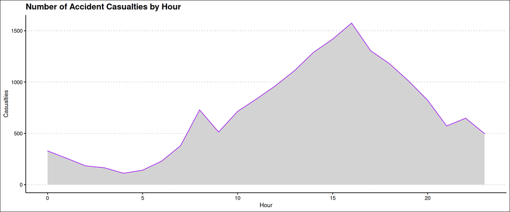

```r
accidents %>%

        ## Get only the major accidents
        filter(number_of_casualties >= 3) %>%

        ## Get the hour of day from the time column
        group_by(hour = hour(time)) %>%

        ## Get total casualties by hour of day
        summarise(death_by_hour = sum(number_of_casualties)) %>%

        ## Plot deaths against hour
        ggplot(mapping = aes(x = hour, y = death_by_hour)) +

  geom_area(col = "purple", fill = "lightgray") +

  labs(x = "Hour", y = "Casualties",

       title = "Number of Accident Casualties by Hour")
```

## Are there any patterns in the time of day/ day of the week when major incidents occur?

This section examines unique patterns in the time of the day or day of the week when major accidents occur. Again, if there are regularities, then the ministry could have interventions at these days/ times to reduce incidences of fatal accidents.

### Breaking down accident casualties by the time of day and day of the week.

As noted earlier, lumping together figures could mask heterogeneity in the patterns of accidents by hour of day or day of the week. In this section, I disaggregate this data revealing patterns to each day of the week.

However, Saturdays and Sundays have a markedly different pattern.

Figure 5: Number of Accident Casualties by Day and Hour

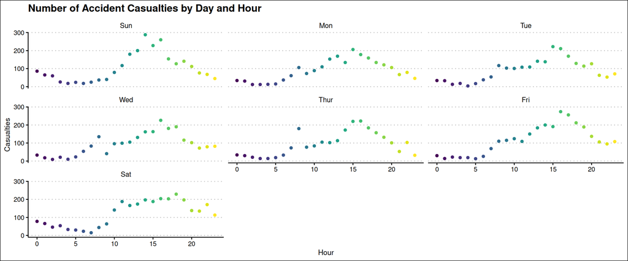

```r
accidents %>%

        ## Get only the major accidents
        filter(number_of_casualties >= 3) %>%

        ## Group by time of day and day of week
        group_by(hour = hour(time), day_of_week) %>%

        ## Get number of deaths by hour
        summarise(death_by_hour = sum(number_of_casualties)) %>%

        ## Plot deaths against hour
        ggplot(mapping = aes(x = hour, y = death_by_hour, col = factor(hour))) +

  geom_point(show.legend = FALSE) +

  facet_wrap(~day_of_week, ncol = 3) +

  scale_color_viridis_d() +

  labs(x = "Hour", y = "Casualties",

       title = "Number of Accident Casualties by Day and Hour")
```

**Insight 7**: Like Sunday, Saturday has one peak in the number of accident casualties. However, the peak accident period is prolonged, lasting from around 11.00 hours to 1800 hours, after which there is a gradual decline.

### Where do accidents happen at weekends vs weekdays?

#### Major Accident Casualties versus Speed Limits

Speed is one major cause of road traffic accidents (Ashraf et al. 2019; Rolison et al. 2018). This section examines the speed limits that correspond with high casualties for major accidents. Figure 6 shows a plot of major accident casualties (y-axis) versus speed limits (x-axis), faceted by day of the week.

Ashraf, Imran, Soojung Hur, Muhammad Shafiq, and Yongwan Park. 2019. “Catastrophic Factors Involved in Road Accidents: Underlying Causes and Descriptive Analysis.” *PLoS One* 14 (10): e0223473.

Rolison, Jonathan J, Shirley Regev, Salissou Moutari, and Aidan Feeney. 2018. “What Are the Factors That Contribute to Road Accidents? An Assessment of Law Enforcement Views, Ordinary Drivers’ Opinions, and Road Accident Records.” *Accident Analysis & Prevention* 115: 11–24.

Figure 6: Speed Limits versus Proportion of major Accident Casualties

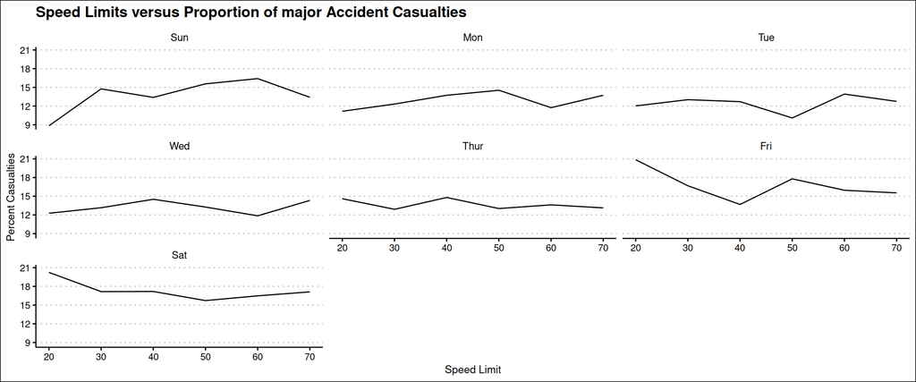

```r
accidents %>%

        ## Get the major accidents
        filter(number_of_casualties >= 3) %>%

        ## Group data by speed limit and day of week
        group_by(speed_limit, day_of_week) %>%

        ## Summarise the total casualties
        summarise(casualties = sum(number_of_casualties)) %>%

        ## Get the sum of casualties
        mutate(perc_casualties = casualties / sum(casualties) * 100) %>%

        ## Plot speed limit versus proportion of casualties
        ggplot(mapping = aes(x = speed_limit, y = perc_casualties)) +

        geom_line() + facet_wrap(~ day_of_week) +

        labs(x = "Speed Limit", y = "Percent Casualties",

       title = "Speed Limits versus Proportion of major Accident Casualties")
```

Jacobs, GD, and I Sayer. 1983. “Road Accidents in Developing Countries.” *Accident Analysis & Prevention* 15 (5): 337–53.

Figure 7: Accident Casualties by Weekday and Speed Limit

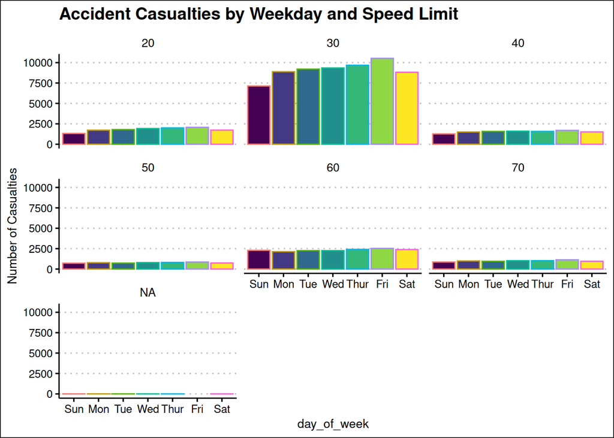

```r
accidents %>%

        ## Create a column of major and minor accidents
        mutate(major = case_when(

                number_of_casualties >= 3 ~ "Major",

                TRUE ~ "Minor"
        )) %>%

        ## Group by day of week and speed limit
        group_by(day_of_week, speed_limit) %>%

        ## Summarise total casualties
        summarise(total = sum(number_of_casualties)) %>%

        ## Plot day of week versus casualties
        ggplot(mapping = aes(x = day_of_week, y = total,

                             col = day_of_week, fill = day_of_week)) +

        geom_col(show.legend = FALSE) +

        facet_wrap(~ speed_limit) +

        scale_fill_viridis_d() +

        labs(y = "Number of Casualties",

             title = "Accident Casualties by Weekday and Speed Limit")
```

#### Major Accident Casualties and Weather Conditions

Another probable driver of accidents is the weather. I tabulate weather conditions against the number of major accident casualties. The results are in Table 5.

**Insight 9**: Table 5 below shows that about 77% of major accident casualties happen when the weather is fine (that is, fine with no high winds). In comparison, 14% occurs when raining with no high winds. Appendix 2 (Figure 12) shows a bar graph showing the proportions of accident casualties by weather condition.

```r
accidents %>%

        ## Get only the major accidents
        filter(number_of_casualties >= 3) %>%

        ## Group by weather conditions
        group_by(weather_conditions) %>%

        ## Get the total number of casualties
        summarise(casualties = sum(number_of_casualties)) %>%

        ## Compute the proportion of casualties
        mutate(perc_casualties = casualties / sum(casualties) * 100) %>%

        ## Sort by casualties
        arrange(desc(casualties)) %>%

        ## Make a nice table
        kbl(., booktabs = TRUE,

            caption = "Table 5: Weather Conditions and Accident Casualties") %>%

        kable_classic(full_width = FALSE, position = "left")
```

Table 5: Weather Conditions and Accident Casualties

| weather_conditions | casualties | perc_casualties |
| --- | --- | --- |
| 1 | 13093 | 77.1038219 |
| 2 | 2382 | 14.0274424 |
| 5 | 417 | 2.4556858 |
| 8 | 391 | 2.3025735 |
| 4 | 307 | 1.8079030 |
| 9 | 202 | 1.1895648 |
| 7 | 130 | 0.7655615 |
| 3 | 47 | 0.2767799 |
| 6 | 12 | 0.0706672 |

We next break down this weather data into days of the week.

**Insight 10**: Most accidents on any day of the week happen when the weather is fine with no high winds (Figure 8). The second riskiest weather pattern is raining with no high winds. It would follow that people are most likely to speed when the weather is clear, hence the high number of casualties.

Figure 8: Casualties by Day of Week and Weather Conditions

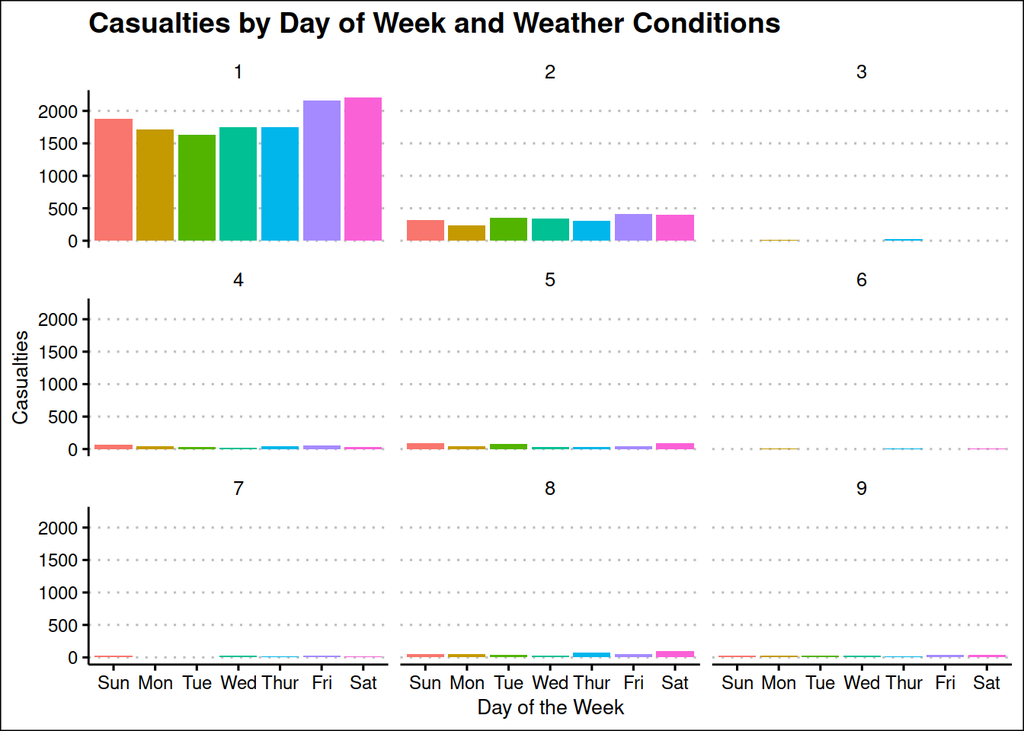

```r
accidents %>%

        ## Get the major accidents
        filter(number_of_casualties >= 3) %>%

        ## Group by weather conditions and day of the week
        group_by(weather_conditions, day_of_week) %>%

        ## Summarise total casualties
        summarise(casualties = sum(number_of_casualties)) %>%

        ## Create new variable for proportion of casualties
        mutate(perc_casualties = casualties / sum(casualties) * 100) %>%

        ## Plot casualties versus day of week
        ggplot(mapping = aes(x = day_of_week, y = casualties,

                       fill = day_of_week)) +

        geom_col(show.legend = FALSE) +

        facet_wrap(~ weather_conditions) +

        labs(x = "Day of the Week", y = "Casualties",

             title = "Casualties by Day of Week and Weather Conditions")
```

## What characteristics stand out in major incidents compared with other accidents?

Figure 9: Accident Type versus Number of Casualties

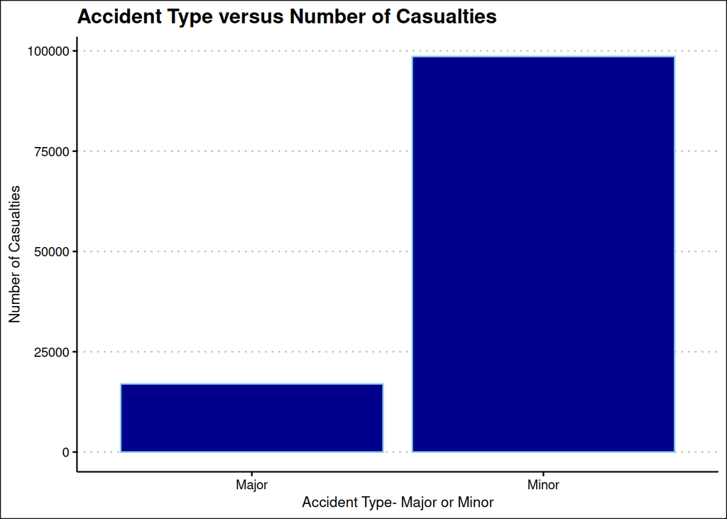

```r
accidents %>%

        ## Create a new column major
        mutate(major = case_when(

                number_of_casualties >= 3 ~ "Major",

                TRUE ~ "Minor"
        )) %>%

        ## Group the data by major
        group_by(major) %>%

        ## Get the total casualties
        summarise(total_casualties = sum(number_of_casualties)) %>%

        ## Plot casualties against major
        ggplot(mapping = aes(x = major, y = total_casualties)) +

        geom_col(col = "skyblue", fill = "darkblue") +

        labs(x = "Accident Type- Major or Minor",

             y = "Number of Casualties",

             title = "Accident Type versus Number of Casualties")
```

**Insight 11**: In comparison to major accidents, minor accidents are more dispersed. Figure 10 shows that major accidents concentrate in three major hotspots, whereas minor accidents concentrate in more places. Note that the figure’s colour `red` shows the accident concentration hotspots.

Figure 10: Major/Minor Accidents Hotspots

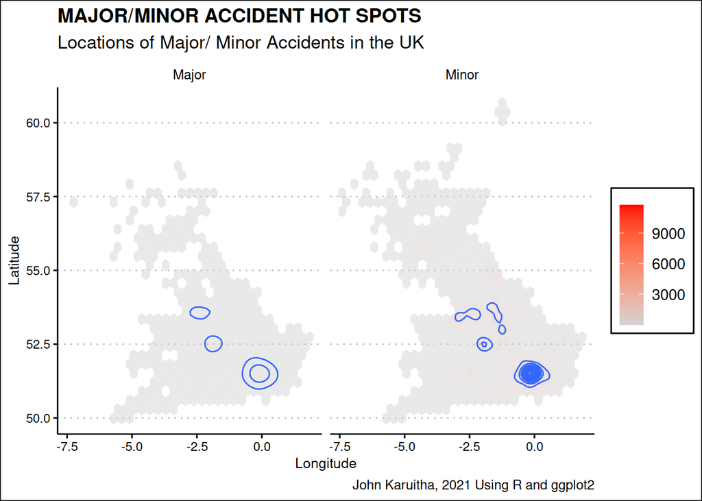

```r
accidents %>%

        ## Create a new column for major and minor accidents
        mutate(major = case_when(

                number_of_casualties >= 3 ~ "Major",

                TRUE ~ "Minor"
        )) %>%

        ## Group by major/ minor accident
        group_by(major) %>%

        ## Map the locations of accidents
        ggplot(mapping = aes(x = longitude, y = latitude)) +

  geom_hex(alpha = 0.5) +

  geom_density_2d() +

  labs(x = "Longitude", y = "Latitude",

       title = "MAJOR/MINOR ACCIDENT HOT SPOTS",

       subtitle = "Locations of Major/ Minor Accidents in the UK",

       caption = "John Karuitha, 2021 Using R and ggplot2") +

  theme(legend.title = element_blank()) +

  scale_fill_gradient(low = "lightgray", high = "red") +

        ## Facet accidents by major/minor category
        facet_wrap(~ major)
```

**Insight 12**: Furthermore, major accidents fatalities appear evenly distributed across rural and urban settings. In contrast, over 2/3 of minor accidents happen in urban areas.

```r
## The data
accidents %>%

        ## Create a major/minor columns
        mutate(major = case_when(

                number_of_casualties >= 3 ~ "Major",

                TRUE ~ "Minor"
        )) %>%

        ## Group by major and urban/rural area
        group_by(major, urban_or_rural_area) %>%

        ## Get total of casualties
        summarise(total = sum(number_of_casualties)) %>%

        ## Make a wide dataset
        pivot_wider(names_from = "major", values_from = "total") %>%

        ## Make a nice table
        kbl(., booktabs = TRUE,

  caption = "Table 6: Casualties in Rural/Urban Settings for Major and Minor Accidents") %>%

        kable_classic(full_width = FALSE,
                                                                                     latex_options = "hold_position", position = "left")
```

Table 6: Casualties in Rural/Urban Settings for Major and Minor Accidents

Major

Minor

1

8680

66142

2

8301

32444

3

17

Next, I examine the number of casualties by speed limit for major and minor accidents. The bar chart below shows the distribution showing a significant difference between major and minor accidents. Compared to other accidents, a significantly lower proportion of casualties happen at a speed limit of 30 mph. In contrast, more accident casualties occur at the 60 mph speed limit for major accidents than minor accidents.

Figure 11: Speed Limits versus Proportion of Accident Casualties

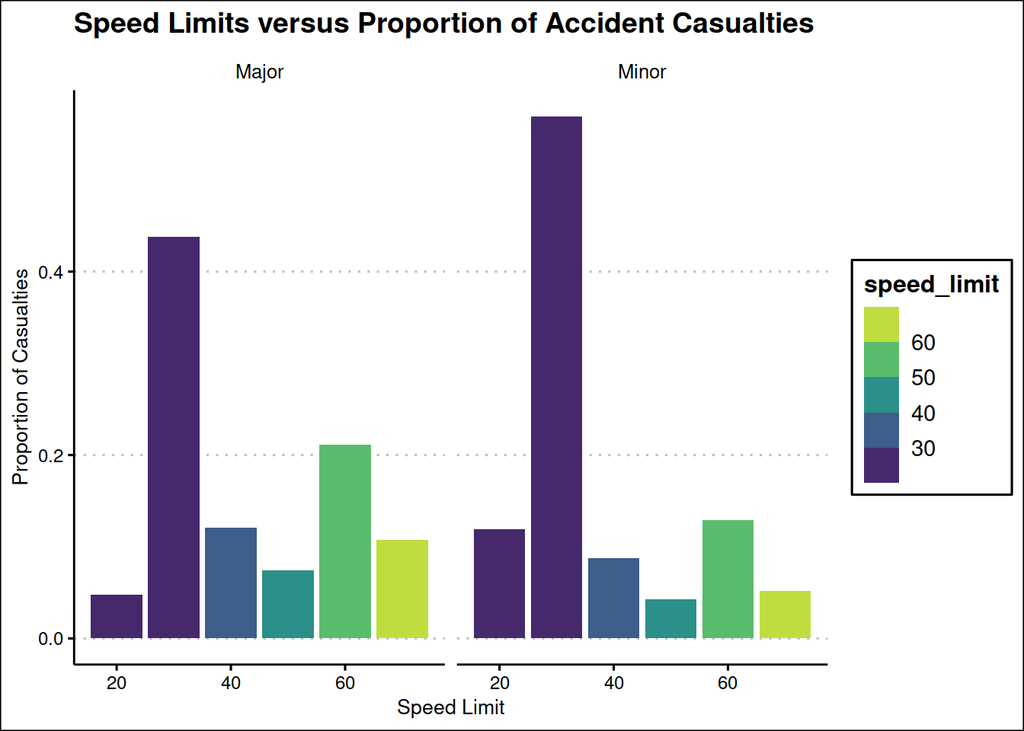

```r
accidents %>%

        ## Create a major/minor accidents column
        mutate(major = case_when(

                number_of_casualties >= 3 ~ "Major",

                TRUE ~ "Minor"
        )) %>%

        ## Group by major and speed limit
        group_by(major, speed_limit) %>%

        ## Summarise total casualties
        summarise(casualties = sum(number_of_casualties)) %>%

        ungroup() %>%

        group_by(major) %>%

        ## Create a new column for proportion of casualties
        mutate(prop = casualties/ sum(casualties)) %>%

        ## Plot prop against speed limit
        ggplot(mapping = aes(x = speed_limit, y = prop, fill = speed_limit)) +

        geom_col() +

        scale_fill_viridis_b() +

        facet_wrap(~ major) +

        ## Add labels and titles
        labs(x = "Speed Limit", y = "Proportion of Casualties",

             title = "Speed Limits versus Proportion of Accident Casualties")
```

## On what areas would I recommend the planning team focus their brainstorming efforts to reduce major incidents?

One of the major takeaways from the analysis is that most road accidents happen when the weather is clear (77%), with another 14% happening when raining but with no high winds. 91% of major accidents occur during these two weather patterns to restate the point. The first recommendation is for the ministry to pay attention when the weather is clear and when raining with no high winds. However, we cannot take the weather pattern in isolation. After considering the weather, the ministry should also jointly focus on the recommendations below.

Another significant regularity in the data is the high incidence of accidents at stretches with 30mph and 60mph speed limits. This recommendation draws from insight 8 and insight 9. For some reason, the speed limit of 30 mph is especially notorious for both major and minor accidents, followed by the 60 mph speed limit. Thus, the ministry should put mechanisms to enforce adherence to these speed limits.

## Conclusion

In this analysis, I examined the road accidents data from the UK. The study of the data provided some valuable insights, the major ones being;

- Accident casualties peak during weekends, Starting from Friday and falling on Sunday.
- Accidents casualties vary by time of day.
- Major accidents and accident casualties mainly happen when the weather is fine.
- Major accidents and accident casualties mainly occur in road stretches with speed limits of 30 mph and 60 mph.

The recommendations to reduce significant accidents casualties should hence draw from these insights. None of the proposals would work very well in isolation. What is needed is a package of interventions that would help lower the tide of casualties from significant accidents.

# Bibliography

Ashraf, Imran, Soojung Hur, Muhammad Shafiq, and Yongwan Park. 2019. “Catastrophic Factors Involved in Road Accidents: Underlying Causes and Descriptive Analysis.” PLoS One 14 (10): e0223473.

Jacobs, GD, and I Sayer. 1983. “Road Accidents in Developing Countries.” Accident Analysis & Prevention 15 (5): 337–53.

Rolison, Jonathan J, Shirley Regev, Salissou Moutari, and Aidan Feeney. 2018. “What Are the Factors That Contribute to Road Accidents? An Assessment of Law Enforcement Views, Ordinary Drivers’ Opinions, and Road Accident Records.” Accident Analysis & Prevention 115: 11–24.

# Appendix

## Appendix 1: Summary Statistics

```r
accidents %>%

        ## Select the relevant variables
        select(-accident_index, -accident_reference,

         -accident_year, -day_of_week,

         -date, -time,

         -longitude, -latitude) %>%

        ## Get summary statistics
        skimr::skim_without_charts() %>%

        ## Remove redundant summary statistics
        select(-skim_type, -n_missing) %>%

        ## Make a nice table
        kbl(., booktabs = TRUE, caption = "Table 7: Summary Statistics") %>%

        kable_classic(full_width = TRUE,

                latex_options = "hold_position",

                font_size = 12)
```

Table 7: Summary Statistics

| skim_variable | complete_rate | numeric.mean | numeric.sd | numeric.p0 | numeric.p25 | numeric.p50 | numeric.p75 | numeric.p100 |
| --- | --- | --- | --- | --- | --- | --- | --- | --- |
| accident_severity | 1.0000000 | 2.7682321 | 0.4566821 | 1 | 3 | 3 | 3 | 3 |
| number_of_vehicles | 1.0000000 | 1.8352723 | 0.6772721 | 1 | 1 | 2 | 2 | 13 |
| number_of_casualties | 1.0000000 | 1.2673823 | 0.6814733 | 1 | 1 | 1 | 1 | 41 |
| first_road_class | 1.0000000 | 4.2203204 | 1.4434755 | 1 | 3 | 4 | 6 | 6 |
| first_road_number | 1.0000000 | 790.6660709 | 1580.8177432 | 0 | 0 | 34 | 538 | 9174 |
| road_type | 1.0000000 | 5.2560006 | 1.6848780 | 1 | 6 | 6 | 6 | 9 |
| speed_limit | 0.9998684 | 36.2750173 | 13.8903666 | 20 | 30 | 30 | 40 | 70 |
| junction_detail | 0.9999781 | 3.9349869 | 12.6128945 | 0 | 0 | 2 | 3 | 99 |
| junction_control | 0.5800612 | 3.7193248 | 1.2284939 | 1 | 4 | 4 | 4 | 9 |
| second_road_class | 1.0000000 | 5.5517714 | 1.0151126 | 1 | 6 | 6 | 6 | 6 |
| second_road_number | 0.9999232 | 220.2489692 | 913.7258441 | 0 | 0 | 0 | 0 | 9174 |
| pedestrian_crossing_human_control | 0.9984320 | 0.3551002 | 1.6986016 | 0 | 0 | 0 | 0 | 9 |
| pedestrian_crossing_physical_facilities | 0.9985197 | 1.1885487 | 2.4462881 | 0 | 0 | 0 | 0 | 9 |
| light_conditions | 0.9999890 | 2.0653413 | 1.7476701 | 1 | 1 | 1 | 4 | 7 |
| weather_conditions | 0.9999890 | 1.7020768 | 1.8457741 | 1 | 1 | 1 | 1 | 9 |
| road_surface_conditions | 0.9965350 | 1.3998988 | 0.9164743 | 1 | 1 | 1 | 2 | 9 |
| special_conditions_at_site | 0.9976096 | 0.2477221 | 1.3187224 | 0 | 0 | 0 | 0 | 9 |
| carriageway_hazards | 0.9977193 | 0.1832929 | 1.1497169 | 0 | 0 | 0 | 0 | 9 |
| urban_or_rural_area | 1.0000000 | 1.3232053 | 0.4680310 | 1 | 1 | 1 | 2 | 3 |

## Appendix 2: Proportion of Major/Minor Accidents by Weather Conditions

Figure 12: Proportion of Major/Minor Accidents by Weather Conditions

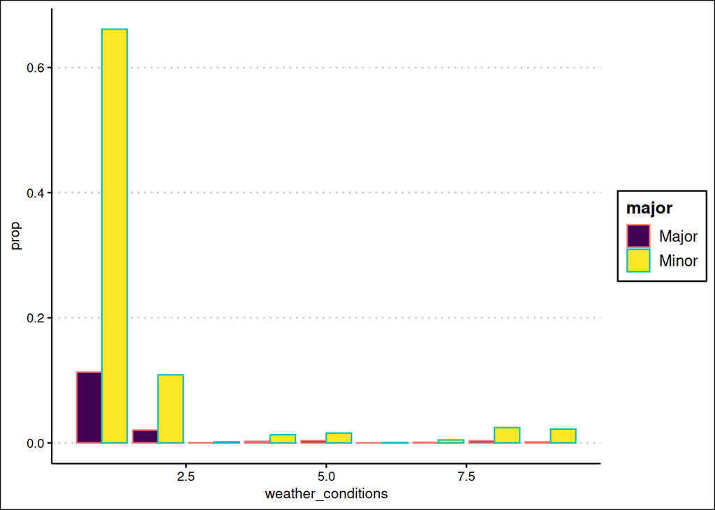

```r
accidents %>%

        mutate(major = case_when(

                number_of_casualties >= 3 ~ "Major",

                TRUE ~ "Minor"
        )) %>%

        group_by(major, weather_conditions) %>%

        summarise(total = sum(number_of_casualties)) %>%

        ungroup() %>%

        mutate(prop = total / sum(total)) %>%

        ggplot(aes(x = weather_conditions, y = prop,

                   fill = major, col = major)) +

        geom_col(position = "dodge") +

        scale_fill_viridis_d()
```